# Project 2

### Assessing Differences in the CA2 Hippocampal Region through the PTPN5 gene

Meenakshi Singhal

BIMM 143, Spring 2022

# Introduction

The hippocampus is a specific and crucial region of the brain; as part of the limbic system, it modulates processes like memory consolidation and facilitates neural plasticity, i.e. long-term potentiation. Thus, this region also becomes a central location of deterioration in neurodegenerative conditions like Alzheimer's disease.

Neuronal populations within the hippocampus are arranged in a highly organized manner; they include mossy and granule cells from the dentate gyrus, as well as CA1, CA2, and CA3 pyramidal cells. For this project, CA2 pyramidal cells in particular will be assessed. While previously considered merely an extension of the CA3, researchers now understand that the CA2 region is its own distinct part of the hippocampus, with unique form and function. CA2 cells have been hypothesized to be largely responsible for facilitating the process of developing social memories that help us navigate interactions (https://www.frontiersin.org/articles/10.3389/fnbeh.2019.00233/full). To this point, interpreting the exact role of the CA2 region based on its neuronal connecitivities has been difficult.

To better understand how this unique brain structure is organized from a metabolic standpoint, various bioinformatics methods and tools will be applied to the RNAseq data. First, a marker gene for the CA2 region can be identified through literature review; the nucleotide sequences for several species found from NCBI can be compared via sequence alignment (See https://iiif.elifesciences.org/lax/14997%2Felife-14997-fig3-figsupp1-v1.tif/full/1500,/0/default.jpg). I chose **PTPN5**, which is tyrosine phosphatase non-receptor type 5. PTPN5 has been implicated in various neurological disorders: elevated levels of PTPN5 have been associated with Alzheimer's disease, schizophrenia, and Parkinson's disease. On the other hand, reduced expression of the protein is associated with several other conditions. Thus, there is belief in the scientific community that PTPN5 plays a fundamental role in modulating synaptic strengthening related to cognitive processes.(https://www.ncbi.nlm.nih.gov/pmc/articles/PMC3149150/). Given the unique cognitive abilities that humans--and more broadly primates--possess, piecing apart these interactions at the gene-level **across species** can make way for a more systematic understanding of the brain. Thus, the PTPN5 gene from three different species will be studies: the mouse, human, and common marmoset.

*The following bioinformatics methods and analyses will be conducted:*

### 1. Pairwise sequence alignment + heatmap: human, mouse, and marmoset sequences

- This step will help establish the basic similarities between the PTPN5 gene for the three species

**FASTA files downloaded from NCI Nucleotide Database**

- mouse: https://www.ncbi.nlm.nih.gov/nuccore/NM_001163565.1?report=fasta
- human: https://www.ncbi.nlm.nih.gov/nuccore/NM_006906.2?report=fasta
- common marmoset: https://www.ncbi.nlm.nih.gov/nuccore/XM_035266003.1?report=fasta

### 2. Homology modeling via SWISS Model: human, mouse

- Make relatively easy visual comparisons between the PTPN5 protein in humans versus in mice, as well as explore specific structural regions where differences occur.

**PDB, .cif, and amino acid FASTA files downloaded from RCSB**

### 3. Multi-sequence alignment + sequence logo generation: human, mouse, and marmoset sequences

- same three FASTA nucleotide files as in step 1.

## Scientific Question:

How has PTPN5--a marker gene for the CA2 hippocampus region--been evolutionarily conserved between mice, humans, and the common marmoset?

## Scientific Hypothesis:

If there are genomic differences between mice, humans, and the common marmoset for the PTPN5 marker gene of the CA2 hippocampus region, then sequence alignment, structural analysis, and sequence logos of the PTPN5 protein will further elucidate evolutionary relationships between the three species.

## Part 1: Load in Packages

- **Biopython**: A set of bioinformatics tools for processing nucleotide, amino acid, etc sequences. It can take in FASTA and other file types and one can also perform BLAST searches.
- **numpy**: A Python library with various functions to build and manipulate array objects; arrays have faster computation than lists due to "behind-the-scenes" C++ frameworks to process the data.
- **matplotlib**: A Python library to easily visualize various plots and graphs; these include scatterplots and bar graphs; usually takes in an independent (x) and dependent (y) variable, with the ability to create axes labels, limits, and a graph title
- **nglview**: A library to visualize molecules like proteins and nucleic acids directly in Jupyter notebooks; used to look at the PTPN5 proteins for both mice and humans that were downloaded from RCSB, as well as the homology model generated in SWISS Model
- **logomaker**: Use to make Sequence Logos for analysis method 3. The functions can be applied to DNA, RNA, or protein-level data; here they will be utilized with multi-alignment sequencing results of the nucleotide sequences of the PTPN5 protein.

```python
import Bio
from Bio import SeqIO  #SeqIO is the input/output interface for Biopython; it allows FASTA files to be read in
import numpy as np #numpy has many convenient mathematical operations and tools
import pandas as pd # pandas is a data processing and organizing library with numerous functions for data analysis and building data structures
import matplotlib.pyplot as plt #for visualizing plots
from Bio import pairwise2 #pairwise2 calculates pairwise sequence alignment between two genes; you can specify whether to calculate global or local alignment scores
from Bio.Seq import Seq #Seq creates string nucleotide objects

from Bio.PDB import * # Biopython package that contains functions related to exploring macromolecular structures
import nglview as nv #visualize PDB protein structures

#!pip install logomaker  #run this step first to install the logomaker library
import logomaker as lm
```

# Part 2A: Performing Bioinformatics Analysis

## Database 1: NCBI Nucleotide search

From the NCBI Nucleotide database, I downloaded FASTA files for the **coding sequences** of the PTPN5 gene for three species: mouse, human, and common marmoset.

```python
# Nucleotide search for PTPN5 in mouse, human, and common marmoset
#mouse_gene, hum_gene, and marmoset_gene are all global variables that store the nucleotide sequence information for their respective species' PTPN5 protein

mouse_gene = next(SeqIO.parse("mouse_gene.fasta.txt", "fasta")) #SeqIO.parse reads in the file as a FASTA
hum_gene = next(SeqIO.parse("hum_gene.fasta.txt", "fasta"))
marmoset_gene = next(SeqIO.parse("marmoset_gene.fasta.txt", "fasta"))
```

```python
#code check
mouse_gene
```

```
SeqRecord(seq=Seq('ATGTGCTGTAGTGAGAGGCTGTTGGGTCTCCCCCAGCCGGTAGAGATGGAAGCA...TGA'), id='lcl|NM_001163565.1_cds_NP_001157037.1_1', name='lcl|NM_001163565.1_cds_NP_001157037.1_1', description='lcl|NM_001163565.1_cds_NP_001157037.1_1 [gene=Ptpn5] [db_xref=CCDS:CCDS21294.1] [protein=tyrosine-protein phos…
```

```python
# mouse_seq contains nucleotide sequence for mouse PTPN5 gene (global variable)
# hum_seq contains nucleotide sequence for human PTPN5 gene (global variable)
# monkey_seq contains nucleotide sequence for marmoset PTPN5 gene (global variable)

#gets Seq object of each sequence
mouse_seq = mouse_gene.seq
hum_seq = hum_gene.seq
mar_seq = marmoset_gene.seq

#code check
len(hum_seq)
```

```
1698
```

```python
#gene_list is a global variable containing the gene sequences in the form of a list
gene_list = [mouse_seq, hum_seq, mar_seq]

gene_len = len(gene_list) #global variable, integer number equal to the size of gene_list

#code check
print(gene_len)

#use the empty function from Numpy to create an empty matrix of the correct size, such that pairwise comparisons can be made between each of the genes in gene_list
#align_score will later be filled with the alignment score values from each comparison
align_score = np.empty(shape=(len(gene_list),len(gene_list)))
```

```
3
```

## Method 1: Pairwise Sequence Alignment of PTPN5 gene (a marker gene for CA2 region)

```python
#multi_align is a function that performs pairwise sequence alignment for each pair of PTPN5 gene sequences
def multi_align(align_array, gene_len):
    # loop over the PTPN5 nucleotide sequences
    for i in range(gene_len):
        for j in range(gene_len):
        #establish seq_one and seq_two; both are local variables containing unique nucleotide sequences
            seq_one = gene_list[i]
            seq_two = gene_list[j]

            #code check
            print(len(seq_one))
            print(len(seq_two))

        #align_array is a local variable containing the alignment scores of all pairs of nucleotide sequences within the list
        #globalxx is a function that performs pairwise sequence alignment between the first two parameters given. We can also establish whether we want global or local alignment.
            align_array[i,j] = int(pairwise2.align.globalxx(seq_one, seq_two, score_only=True))/len(max(seq_one, seq_two))

    return align_array

# perform multiple sequence alignment between the mouse, human, and marmoset PTPN5 gene via the multi_align function
alignments = multi_align(align_score, gene_len)

#code check for values of alignment scores
alignments
```

```
1626
1626
1626
1698
1626
1581
1698
1626
1698
1698
1698
1581
1581
1626
1581
1698
1581
1581
```

```
array([[1.        , 0.89606396, 0.86777368],
       [0.89606396, 1.        , 0.96394687],
       [0.86777368, 0.96394687, 1.        ]])
```

## Analysis 1: Heat Map

From left to right/top to bottom on the heat map, the species are as follows: mouse, human, marmoset. Based on the results of the heatmap generated below, we can see that the PTPN5 gene sequences for humans and the common marmoset aligned more closely (96% alignment) than when either group is compared to the mouse gene sequence (roughly 86-90% alignment). From an evolutionary perspective, this makes sense; humans are closer to primates on the tree of life than they are to mice, which belong to more distant taxonomical levels. *Given the fact that PTPN5 is a significant marker gene of the CA2 hippocampus region*, we can also begin to infer that there may be differences in brain structure, such that humans and marmosets have more similar CA2 regions than either does with mice. These differences may manifest in the forms of cognition, neurodegeneration, and other molecular processes that PTPN5 could participate in.

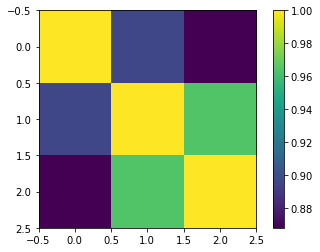

```python
#Create subplot
fig, ax = plt.subplots()

# Visualize heatmap of pairwise alignment by inputting the previously calculated alignment score array
plt.imshow(alignments)

# Show the axes of heatmap
im = ax.imshow(alignments)

# Add colorbar to show strength of relationships between mouse, human, and macaque nucleotides for the RGS 14 gene
cbar = ax.figure.colorbar(im)

# Show the heatmap
plt.show()
```

# Part 2B: Protein Structural Analysis of PTPN5: mouse & human

## Database 2: PDB

From RCSB, I found protein structures (.pdb and .cif files) for both human (2BV5) and murine (6H8S) PTPN5.

#### 6H8S = Murine PTPN5

```python
parser = MMCIFParser() #create a parser object from the Bio.PDB package

mouse_structure = parser.get_structure("6H8S", "6h8s.cif") #mouse_structure global variable holds mouse PTPN5 protein

view = nv.show_biopython(mouse_structure) #use the NGLviewer function show_biopython to see the unique side chains and features, with the ability to rotate and zoom in/out.
view
```

#### 2BV5 = Human PTPN5

```python
parser = MMCIFParser() #create a parser object from the Bio.PDB package

human_structure = parser.get_structure("2BV5", "2bv5.cif") #human_structure holds mouse PTPN5 protein

view = nv.show_biopython(human_structure) #use the NGLviewer function show_biopython to see the unique side chains and features, with the ability to rotate and zoom in/out.

#code check
view
```

## Method 2: Homology modeling and structural bioinformatics

The Homology Modeling workflow is as follows:

1. alignment
2. backbone generation (minimize energy via insertions/deletions of amino acids)
3. loop modeling
4. side-chain modeling
5. model optimization

**goal: create homology model of PTPN5 where template=human, targest sequence=mouse**

### PTPN5 model created in SWISS Model

#### Methods:

- In SWISS Model, the *User template* option was selected:
  - target sequence = 6H8S (mouse) amino acid fasta file from RCSB
  - template file = 2BV5 (human) pdb file from RCSB

#### Results:

https://swissmodel.expasy.org/interactive/4TLzKX/models/

We can see that there are areas of less certainty in the homology structure, which are depicted by the reddish regions.

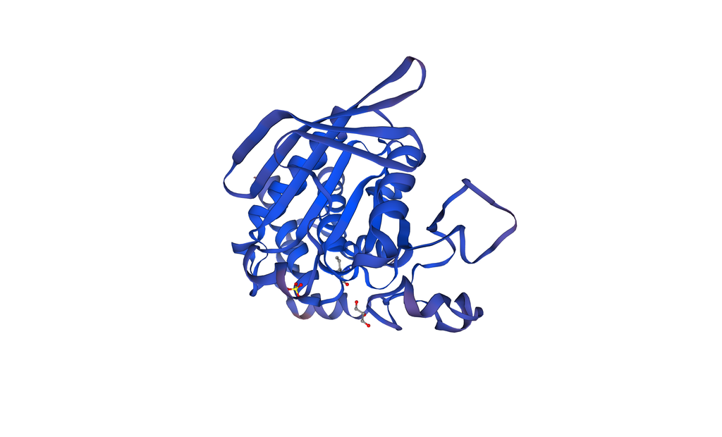

### Ramachandran plot of PTPN5 structure created in SWISS model

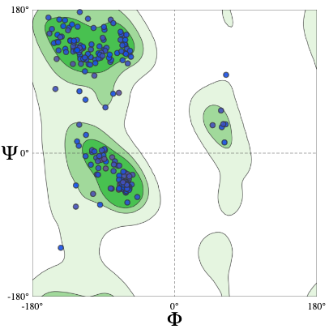

With the Ramachandran plot of the homology model, we can see the distribution of what are sterically feasible amino acid conformations. In the top left are beta sheets (which appear to be slightly more common here), and the bottom left are alpha helices; together, these make up the two most common secondary structures of peptide chains.

### Model quality estimate

We can see the predicted accuracy of each residue within the protein structure; this information can help with determining which specific regions of the PTPN5 to assess and compare more closely, between the different species. Residues around 30, 90, and 180 appear to have lower accuracy.

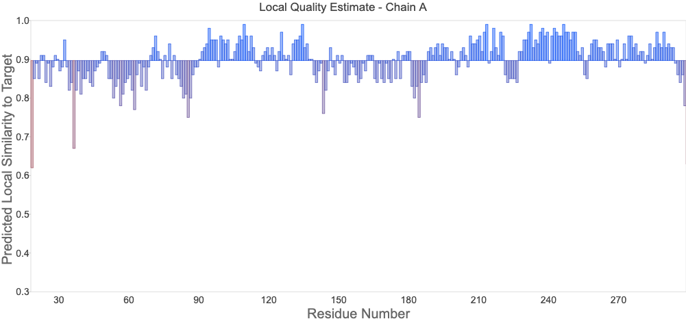

### in PyMOL, comparing SWISS model (yellow) with human PTPN5 protein (orange)

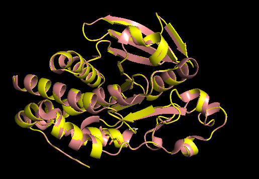

### Comparing SWISS model (yellow) with mouse PTPN5 protein (pink)

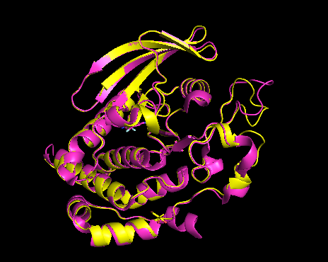

From the above two images showing alignment of the SWISS model with either the human or mouse PTPN5 protein, we can see there are more similarities between SWISS and human, versus with SWISS and mouse. This conclusion would make sense, because during the homology modeling process, I set the human nucleotide sequence to be the template file, while the original mouse PTPN5 sequence was the target sequence. We can also perform more quantitative assessments to compare protein structure.

## Analysis 2: 3D protein measurements

Using the PDB package in Biopython, I can take various measurements of the 3D protein structures. These measurements correlate such that for a given atom or residue, if one set of measurements is closer in value than another set, we can infer that those two proteins are more structurally similar. In particular, I can find two measurements: 1. atomic distance and 2. torsion angle. The **inputs** to the functions I wrote are the .cif files that were either downloaded from RCSB, or from SWISS Model (for the homology model). The **outputs** were measurement values in the form of either distances (Angstroms) or angular degrees.

**goals:**

- compare structures of murine, homology model, and human PTPN5 protein
  - regions that are different suggest some kind of change that happened evolutionarily

```python
##first visualize SWISS homology model of PTPN5 gene

parser = MMCIFParser()

swiss_structure = parser.get_structure("swiss", "swiss_model.pdb.cif") #swiss_structure global variable holds mouse PTPN5 protein

view = nv.show_biopython(swiss_structure)
view
```

#### 1. Atomic Distance

```python
structure_list = [mouse_structure, human_structure, swiss_structure] #global variable containing the pdb objects for each PTPN5 protein
names_list = ['mouse', 'human', 'swiss model'] #global variable containing the names of the proteins as strings

#atomic distance function calculates distances between atoms in specific region for all three proteins: mouse, human, and swiss
def atomic_distance():
    dist_list = [] #local variable that stores values of distances
    for struct in structure_list:

        #unfold_entities() is is Bipython PDB function that reads in the variable to be opened, and returns a list of the selected entity type.
        #Here, the input is each of the three PTPN5 pdb structures, and the "R" signifies that all of the Residues from the given structure should be unfolded. "C" can be used to represent chains, and "A" can represent atoms.
        res_list = Selection.unfold_entities(struct, "R") #local variable that stores residues within the given protein structure

        #code check, gets name of the first residue in each protein structure
        print(res_list[0].get_resname())
        print(len(res_list))

        # Get atoms
        ca1 = res_list[85]["CA"] #local variable that stores information of the first chosen atom (alpha carbon) in the given residue
        ca2 = res_list[84]["N"] #local variable that stores information of the second chosen atom (nitrogen) in the given residue

        # Subtract the atoms to get their distance
        distance = ca1 - ca2     #local variable that holds the distance in Angstroms between both atoms
        dist_list.append(distance)
    dist_dict = {names_list[i]: dist_list[i] for i in range(len(names_list))} #local variable; this dictionary connects the species name to the given protein measurement
    return dist_dict
atomic_distance()
```

```
SER
569
SER
555
SER
284
```

```
{'mouse': 4.8807793, 'human': 4.2134614, 'swiss model': 4.266269}
```

We can see that for the given residues (84 and 85) and atoms (alpha carbon, nitrogen), the human and swiss model PTPN5 proteins have more similar measurements than either does with the mouse protein structure. These results suggest that the homology modeling procedures indeed create a structure more similar to the template than the original target sequence.

#### 2. Torsion Angle

```python
#torsion angle function calculates torsion angle between atoms in specific region for all three proteins: mouse, human, and swiss
def torsion_angle():
    angle_list = [] #local variable that stores values of torsion angles
    for struct in structure_list:
        chains = Selection.unfold_entities(struct, "C") #local variable holding the chains within the structure
        atom_list = Selection.unfold_entities(chains[0], "A") #local variable holding all the atoms in the given chain

        #local variables holding the information of the chosen atom
        atom1 = atom_list[190]
        atom2 = atom_list[191]
        atom3 = atom_list[192]
        atom4 = atom_list[193]

        #code check
        print(atom3.get_fullname())

        #local variables that each hold the vector coordinates of the given atom
        vector1 = atom1.get_vector()
        vector2 = atom2.get_vector()
        vector3 = atom3.get_vector()
        vector4 = atom4.get_vector()

        ## calc_dihedral is a function from the Biopython PDB package, that takes in four vectors and returns angle
        angle = calc_dihedral(vector1, vector2, vector3, vector4) #local variable that contains the calculate torsion angle

        angle_list.append(angle)

    #local variable; this dictionary combines the species name labels with the given PTPN5 measurement
    torsion_dict = {names_list[i]: angle_list[i] for i in range(len(names_list))}
    return torsion_dict

torsion_angle()
```

```
N
CG
CA
```

```
{'mouse': 0.8815270168744962,
 'human': 1.5716171438601858,
 'swiss model': -2.592423150505309}
```

We can see that when we call torsion_angle(), there is considerable difference in the values between the three species. This result suggests that at the specific atoms chosen (190-193), even homology modeling was not able to accurately recapture the structure of the human PTPN5 protein. Moreover, this region may be significant from a biological perspective, because perhaps there is something unique to the human PTPN5 protein in terms of its overall molecular composition/function, that translates to having a specific conformation in this region.

# Part 2C: Multi sequence alignment + Sequence Logos

To come full circle and reinforce initial conclusions, the data for the common marmoset PTPN5 sequence will once more be analyzed.

## Analysis 3: Sequence Logos

Sequence logos are a way to visualize the conservation of amino acids in a given sequence. The relative size of the letter at a given position is proportional to its frequency. We can thus use this analysis method to further assess the evolutionary relationships of the CA2 hippocampus region between humans, mice, and the common marmoset, through the lens of the PTPN5 gene.

```python
#load in the multi-sequence alignment file
with open('multiseq.fasta') as f:
    lines = f.readlines()

# preview loaded file
print(''.join(lines[:10]))
```

```
>lcl|XM_035266003.1_cds_XP_035121894.1_1
----------------------------------------
----------------------------------------
-------------------------------------ATG
GAGGCGCCGGACAAGGTCGAAAGGCTCCAGGACTCACCAA
GAGAGATGCCACCACCCCCTCCTCCCTCGCCGCCTTCAGA
CCCAGCTCAGAAGCCACCACCTCAAGGCACTGGGAGCCAC
TCCCTCACTGTCAGGAGCAGCCTGTGCCTGTTCGCTGCCT
CGCAGTTCCTGCTTGCCTGCGGGGTGCTCTGGTTCAGCGG
CTATGGCCACATCTGGTCACAGAACGCCACAAACCTCGTC
```

```python
# extract nucleotide sequences from FASTA-formatted inputs
#seqs is a global variable containing an array of nucleotide sequences that were previously aligned
seqs = [seq.strip().upper() for seq in lines if ('#' not in seq) and ('>') not in seq]


#remove last line of each of the three nucleotide sequences for the three different species.
seqs = seqs[0:42]+seqs[43:85]+seqs[86:128]


print('There are %d sequences, all of length %d'%(len(seqs), len(seqs[0])))

#code check
seqs
```

```
There are 126 sequences, all of length 40
```

```
['----------------------------------------',
 '----------------------------------------',
 '-------------------------------------ATG',
 'GAGGCGCCGGACAAGGTCGAAAGGCTCCAGGACTCACCAA',
 'GAGAGATGCCACCACCCCCTCCTCCCTCGCCGCCTTCAGA',
 'CCCAGCTCAGAAGCCACCACCTCAAGGCACTGGGAGCCAC',
 'TCCCTCACTGTCAGGAGCAGCCTGTGCCTGTTCGCTGCCT',
 'CGCAGTTCCTGCTTGCCTGCGGGGTGCTCTGGTTCAGCGG',
 'CTATGGCCACATCTGGTCACAGAACGCCACAAACCTCGTC',
 'TCCTCTTTGCT-ATGCTCCTGAAACAGCTGGGACCCATGG',
 'CCTGGCTTGGCTCTGGGACGTGGGGAGTCCCCAGTCTGCT',
 'GCTCGTCTCTCTGTCCATGGGCCTTGTCCTCATTACCACC',
 'CTGGTGTGGCACCTCCTGAGGACACCCCCAGAGCCACCCA',
 'CTCCACTGCCCCCTGAGGACAGGCGCCAGTCAGTGAGTCG',
 'CCAGCCCTCCTTCACCTACTCTGAGTGGATGGAGGAGAAA',
 'GTTGAAGATGACTTCCTGGACCTGGACCCGGTGCCTGAGA',
 'CTCCTGTGTTTGATTGTGTGATGGACATCAAGCCTGAGGC',
 'TGACCCTGCCTCACTCACCGTCAAGTCCATGGGTCTGCAG',
 'GAGAGGAGGGGCTCCAATGTCTCGCTGACCCTGGACATGT',
 'GCACACCGGGCTGCAACGAGGACGGCTTTGGCTATCTCAT',
 'GTCCCCACGGGAGGAGTCAGCGCGCGAGTACCTGCTCAGC',
 'GCCTCCCGTGTCCTCCAAGCAGAAGAGCTTCACGAAAAGG',
 'CCCTGGACCCTTTCCTGCTGCAGGCGGAATTCTTTGAAAT',
 'CCCCATGAACTTTGTTGATCCAAAAGAGTACAACATCCCT',
 'GGGCTGGTGCGGAAGAACCGGTACAAAACCATACTTCCCA',
 'ACCCTCACAGCAGAGTGTGTCTGACATCACCAGACCCTGA',
 'CGACCCTCTGAGTTCCTACATTAATGCCAACTACATCCGG',
 'GGCTACGGTGGGGAGGAGAAGGTGTACATCGCCACTCAGG',
 'GACCCATCGTCAGCACGGTCGCCGACTTCTGGCACATGGT',
 'ATGGCAGGAGCACACGCCCATCATTGTCATGATCACCAAC',
 'ATCGAGGAGATGAACGAGAAATGCACCGAGTATTGGCCGG',
 'AGGAGCAGGTGGTGTACGACGGTGTTGAGATCACTGTGCA',
 'GAAAGTCATTCACACTGAGGATTACCGGCTACGGCTCATC',
 'TCCCTCAAGAGTGGGACTGAGGAGCGAGGCCTGAAGCATT',
 'ACTGGTTCACATCCTGGCCAGACCAGAAGACCCCAGACCG',
 'GGCACCCCCACTCCTGCACCTGGTGCGGGAGGTGGAGGAG',
 'GCAGCCCAACAGGAGGGGCCCCACTGTGCCCCCATCATCG',
 'TCCACTGCAGTGCAGGGATTGGAAGGACTGGCTGCTTCAT',
 'TGCCACCAGCATCTGCTGCCAGCAGCTGCGGCAGGAGGGT',
 'GTGGTGGACATCCTGAAGACCACATGCCAGCTCCGTCAGG',
```

[output cut: 71 more lines]

```
 'GGCTACAGTGGGGAGGAGAAGGTGTACATCGCCACGCAGG',
 'GACCCATCGTCAGCACTGTGGCCGACTTTTGGCGCATGGT',
 'GTGGCAGGAGCGCACACCCATCATCGTCATGATCACCAAC',
 'ATCGAGGAGATGAACGAGAAGTGCACAGAATACTGGCCAG',
 'AAGAGCAGGTGGTCCATGACGGCGTGGAGATCACCGTGCA',
 'GAAAGTCATCCACACGGAGGACTACCGGCTGCGACTCATC',
 'TCCCTCAGGAGAGGGACTGAAGAGCGAAGCTTGAAGCATT',
 'ACTGGTTCACATCCTGGCCTGACCAGAAGACCCCCGACCG',
 'GGCTCCCCCACTCCTGCACCTGGTACGGGAAGTGGAGGAG',
 'GCAGCCCAACAAGAGGGACCCCATTGTTCCCCAATCATCG',
 'TTCACTGCAGTGCAGGGATTGGGAGAACTGGCTGCTTCAT',
 'TGCCACCAGCATCTGCTGCCAGCAGCTGCGACGTGAGGGC',
 'GTGGTGGACATCCTGAAGACCACGTGCCAGCTCCGTCAGG',
 'ACAGGGGTGGCATGATCCAGACATGCGAACAGTACCAGTT',
 'TGTGCACCACGCCATGAGCCTCTATGAGAAGCAGCTGTCC']
```

```python
# create counts_df, which is a global variable matrix that represents the frequency of each nucleotide existing at the certain location
#alignment_to_matrix is a function from Logomaker that performs this dataprocessing; we can also choose which characters to ignore, such that the only bins are the four nucleotides (A, C, T, G)
counts_df = lm.alignment_to_matrix(sequences=seqs, to_type='counts', characters_to_ignore='.-')

#code check
counts_df
```

| pos | A | C | G | T |
| --- | --- | --- | --- | --- |
| 0 | 20.0 | 30.0 | 47.0 | 24.0 |
| 1 | 20.0 | 47.0 | 24.0 | 30.0 |
| 2 | 26.0 | 55.0 | 27.0 | 13.0 |
| 3 | 24.0 | 39.0 | 37.0 | 21.0 |
| 4 | 20.0 | 39.0 | 38.0 | 24.0 |
| 5 | 17.0 | 51.0 | 31.0 | 22.0 |
| 6 | 23.0 | 33.0 | 28.0 | 37.0 |
| 7 | 27.0 | 44.0 | 33.0 | 17.0 |
| 8 | 27.0 | 27.0 | 45.0 | 22.0 |
| 9 | 15.0 | 43.0 | 45.0 | 18.0 |
| 10 | 29.0 | 32.0 | 25.0 | 35.0 |
| 11 | 23.0 | 34.0 | 26.0 | 37.0 |
| 12 | 21.0 | 47.0 | 30.0 | 23.0 |
| 13 | 37.0 | 29.0 | 19.0 | 36.0 |
| 14 | 15.0 | 39.0 | 44.0 | 23.0 |
| 15 | 28.0 | 33.0 | 48.0 | 12.0 |
| 16 | 25.0 | 29.0 | 37.0 | 30.0 |
| 17 | 24.0 | 38.0 | 42.0 | 17.0 |
| 18 | 35.0 | 38.0 | 29.0 | 19.0 |
| 19 | 25.0 | 40.0 | 36.0 | 20.0 |
| 20 | 27.0 | 36.0 | 38.0 | 20.0 |
| 21 | 23.0 | 37.0 | 39.0 | 22.0 |
| 22 | 35.0 | 31.0 | 36.0 | 19.0 |
| 23 | 43.0 | 23.0 | 41.0 | 14.0 |
| 24 | 22.0 | 36.0 | 35.0 | 28.0 |
| 25 | 21.0 | 35.0 | 49.0 | 16.0 |
| 26 | 28.0 | 36.0 | 32.0 | 25.0 |
| 27 | 28.0 | 47.0 | 29.0 | 17.0 |
| 28 | 38.0 | 38.0 | 22.0 | 23.0 |
| 29 | 30.0 | 36.0 | 26.0 | 29.0 |
| 30 | 17.0 | 39.0 | 47.0 | 18.0 |
| 31 | 28.0 | 36.0 | 36.0 | 21.0 |
| 32 | 31.0 | 29.0 | 29.0 | 33.0 |
| 33 | 25.0 | 40.0 | 35.0 | 22.0 |
| 34 | 28.0 | 52.0 | 22.0 | 20.0 |
| 35 | 27.0 | 29.0 | 23.0 | 43.0 |
| 36 | 24.0 | 52.0 | 31.0 | 15.0 |
| 37 | 42.0 | 40.0 | 24.0 | 17.0 |
| 38 | 26.0 | 33.0 | 46.0 | 18.0 |
| 39 | 22.0 | 25.0 | 45.0 | 31.0 |

```python
# filter which positions are depicted in sequence logo, base on number of counts

num_seqs = counts_df.sum(axis=1) #global variable that calculates sum of each row of counts_df

#code check
print(num_seqs)

true_pos = num_seqs > len(seqs)/2 #global variable, contains Booleans for whether each row of seqs should be retained for final sequence logo

#code check
print(true_pos)

counts_df = counts_df[true_pos]
counts_df.reset_index(drop=True, inplace=True)
```

```
pos
0     121.0
1     121.0
2     121.0
3     121.0
4     121.0
5     121.0
6     121.0
7     121.0
8     121.0
9     121.0
10    121.0
11    120.0
12    121.0
13    121.0
```

[output cut: 69 more lines]

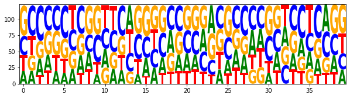

```python
#visualize sequence logo
lm.Logo(counts_df);
```

We can see that there do not appear to be many significantly conserved regions in the PTPN5 gene, across the three species. The heights of the nucleotides appear to be relatively the same. In general, there appear to be more C and G motifs than A and T, if we read the consensus sequence as the top-most string of nucleotides.

```python
#converting counts sequence logo to information sequence logo
info_mat = lm.transform_matrix(counts_df,
                                      from_type='counts',
                                      to_type='information')
```

[output not shown]

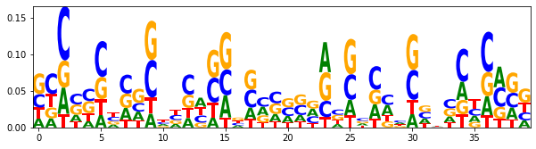

```python
lm.Logo(info_mat)
```

From the above sequence logo based on information, we can now see which specific positions hold more informationall value (based on the total height of the nucleotide stack). We can now better see that C and G appear with greater frequency in the alignments.